# Breast cancer

Mariana Pasqualini

10/15/2020

## Pacotes

```r
library(tidyverse)
library(janitor)
library(GGally)
library(caret)
library(printr)
library(corrplot)
library(factoextra)
library(pROC)

set.seed(675)
```

## Explorando os dados: Correlações e separabilidade das classes

### Mean

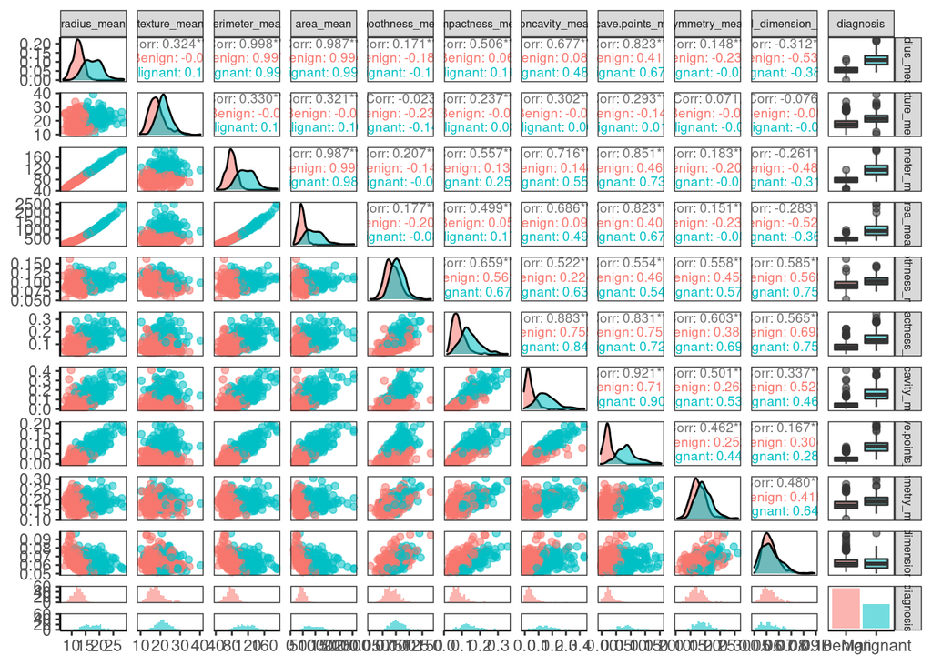

É possível ver rapidamente que algumas variáveis estão correlacionadas fortemente entre si.

Algumas variáveis apresentam correlação positiva quase perfeita (muito próximo de 1), como

- **radius_mean** e **perimeter_mean** (0.998)
- **radius_mean** e **area_mean** (0.987)
- **perimeter_area** e **area_mean** (0.987)

Outras variáveis também apresentam uma correlação forte (acima de 0.5), como

- **concavity_mean** e **compactness_mean** (0.883)
- **concave.points_mean** e **concavity_mean** (0.921)
- **concave.points_mean** e **perimeter_mean** (0.851)

Quanto à separabilidade dos dados, observando os histogramas, parece que as variáveis **radius_mean**, **perimeter_mean**, **area_mean** e **concavity_mean** ajudam a melhor identificar as populações *benigno* e *maligno*, mas ainda assim vemos sobreposições e nenhuma variável parece separar perfeitamente essas classes.

### Standard Error

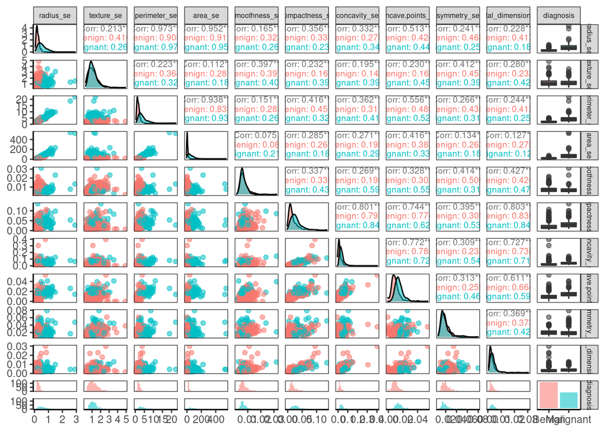

As correlações do erro padrão dessas variáveis são, de maneira geral, um pouco mais baixas, mas ainda sim temos correlações fortes nas mesmas variáveis da média.

Quanto à separabilidade das classes, as variáveis parecem não ajudar a identificar as duas populações.

### Worst

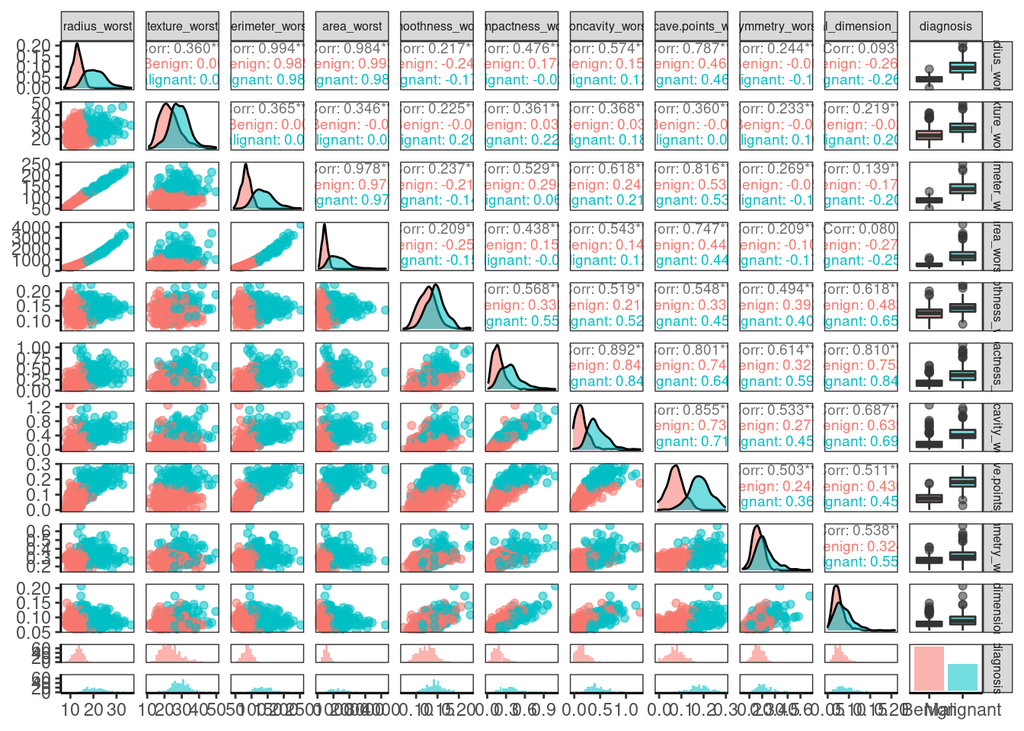

Os scatterplots dessas variáveis, que são as médias dos maiores valores, também são bem parecidas com as observadas para as médias.

Por meio das variáveis **concave.points_worst**, **radius_worst** e **perimeter_worst** parecem ser as que mais ajudam separar as classes do diagnóstico.

Quando uma variável tem correlação perfeita, sabendo o valor da variável X, conseguimos prever o de Y. Com isso, podemos escrever X em função de Y (ou vice-versa). E observamos nas matrizes acima que algumas variáveis têm correlação bem alta.

Trabalhar com dados altamente correlacionados:

- Não acrescenta informação da variabilidade dos dados
- Os modelos podem levar mais tempo que o necessário para serem ajustados

Para ajudar nesse problema, vamos recorrer à técnicas de redução de dimensionalidade.

## PCA: Reduzindo a dimensão

Análise de componentes principais é uma técnica de fatorização de matriz em que é possível explicar (parte da) a variabilidade dos dados por meio de combinações lineares não correlacionadas dos dados originais. De maneira geral, a ideia de fatorar uma matriz é escrever uma matriz “complicada” no produto de duas matrizes “mais simples”.

Vamos definir as componentes principais por meio de operações matriciais, para conhecer todo o processo.

1. Estimando a matriz de correlação:

O primeiro passo é estimar a matriz de correlação dos nossos dados. Na verdade, nessa etapa usa-se a matriz de covariâncias, mas um problema que pode surgir é que algumas variância são maiores que outras, e em casos muito discrepantes isso distorce as componentes principais. Para evitar isso, o procedimento é: padronizar a matriz de covariâncias e estimar as componentes a partir dessa matriz padronizada. Mas isso é o mesmo que usar a matriz de correlação e por isso vou seguir por ela.

```r
upper <- cor_matrix
upper[upper.tri(cor_matrix)] <- NA

knitr::kable(upper[1:5, 1:5],  caption = "Matriz de correlação: 5 primeiras linhas/colunas")
```

Matriz de correlação: 5 primeiras linhas/colunas

|  | radius_mean | texture_mean | perimeter_mean | area_mean | smoothness_mean |
| --- | --- | --- | --- | --- | --- |
| radius_mean | 1.0000000 |  |  |  |  |
| texture_mean | 0.3237819 | 1.0000000 |  |  |  |
| perimeter_mean | 0.9978553 | 0.3295331 | 1.0000000 |  |  |
| area_mean | 0.9873572 | 0.3210857 | 0.9865068 | 1.0000000 |  |
| smoothness_mean | 0.1705812 | -0.0233885 | 0.2072782 | 0.1770284 | 1 |

2. Obtendo os autovalores:

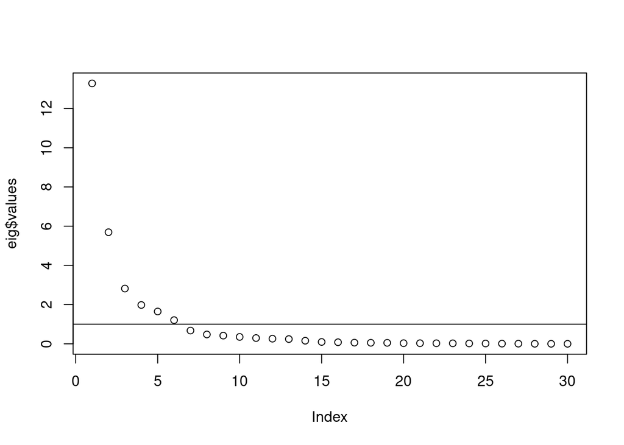

```r
eig$values
##  [1] 1.328161e+01 5.691355e+00 2.817949e+00 1.980640e+00 1.648731e+00
##  [6] 1.207357e+00 6.752201e-01 4.766171e-01 4.168948e-01 3.506935e-01
## [11] 2.939157e-01 2.611614e-01 2.413575e-01 1.570097e-01 9.413497e-02
## [16] 7.986280e-02 5.939904e-02 5.261878e-02 4.947759e-02 3.115940e-02
## [21] 2.997289e-02 2.743940e-02 2.434084e-02 1.805501e-02 1.548127e-02
## [26] 8.177640e-03 6.900464e-03 1.589338e-03 7.488031e-04 1.330448e-04

plot(eig$values)
abline(h = 1)
```

Para estimar o número de componentes principais ideal, um critério prático é observar os autovalores maiores ou iguais a 1, pois dessa forma as combinações lineares explicam a variância de uma variável original (padronizada) do dataset. Observando o scree-plot acima, é **k = 6** é o número de componentes principais adequados para explicar a estrutura da variância dos dados.

3. Obtendo os autovetores e escrevendo a 1ª componente principal:

Observando os autovetores associados aos seis autovalores identificados (apenas as 6 primeiras linhas de 30)

| V1 | V2 | V3 | V4 | V5 | V6 |
| --- | --- | --- | --- | --- | --- |
| -0.2189024 | -0.2338571 | -0.0085312 | 0.0414090 | 0.0377864 | 0.0187408 |
| -0.1037246 | -0.0597061 | 0.0645499 | -0.6030500 | -0.0494689 | -0.0321788 |
| -0.2275373 | -0.2151814 | -0.0093142 | 0.0419831 | 0.0373747 | 0.0173084 |
| -0.2209950 | -0.2310767 | 0.0286995 | 0.0534338 | 0.0103313 | -0.0018877 |
| -0.1425897 | 0.1861130 | -0.1042919 | 0.1593828 | -0.3650885 | -0.2863745 |
| -0.2392854 | 0.1518916 | -0.0740916 | 0.0317946 | 0.0117040 | -0.0141309 |

Olhando um pouco para a teoria, a j-ésima componente principal é dada por:

$$Ŷ_j = ê_{j1}X_{1} + ê_{j2}X_{2} + ... + ê_{jp}X_{p}$$

E podemos escrever, para os dados do dataset em questão, a primeira componente principal da seguinte forma:

$$Ŷ_1 = -0.2189\text{radius_mean} -0.1037\text{texture_mean} - 0.227\text{perimeter_mean} + ... - 0.132\text{fractal_dimension_worst}$$

E assim em diante…

Mas como visualizações são mais interessantes, vamos construir gráficos!

#### Visualizando as componentes principais

Bom, como a função *fviz_pca_biplot* do pacote *factoextra* faz um gráfico apropriado a partir de um objeto da classe PCA, vou utilizar a função *princomp* (do stats, que faz parte do R base) para criar esse objeto. Essa função foi escolhida porque ela usa o **teorema da decomposição espectral**, que é a abordagem teórica utilizada na descrição acima. Caso a abordagem fosse **decomposição em valores singulares** (SVD), a função apropriada seria a *prcomp* (também do *stats*).

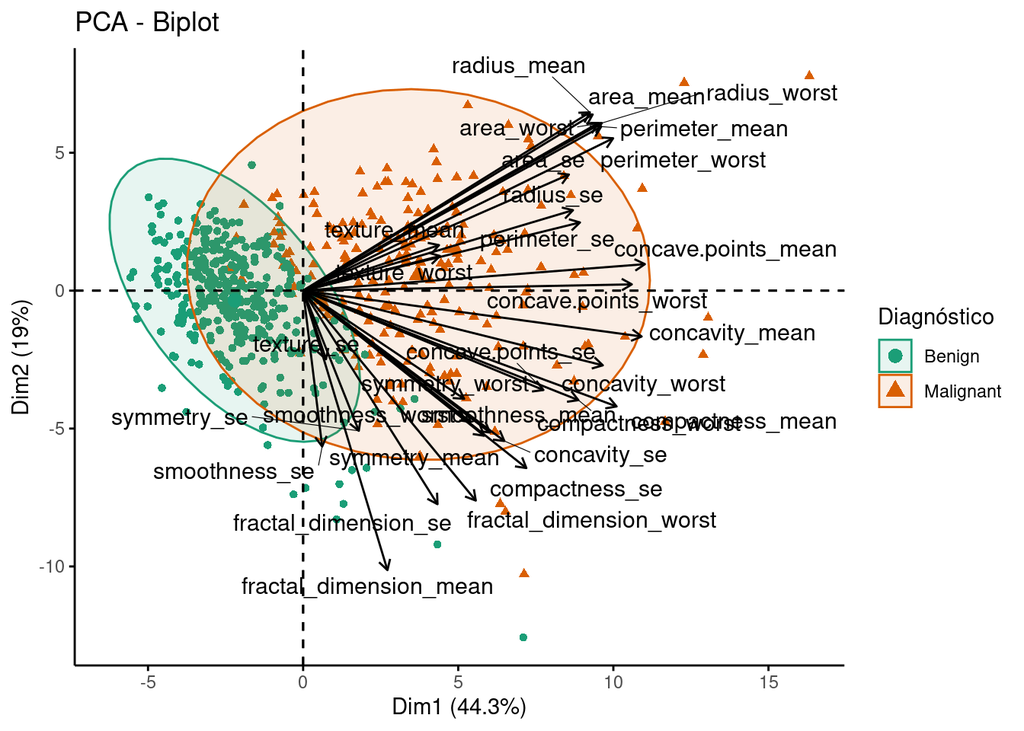

```r
pca <- princomp(data_processed[,-1], cor = TRUE, scores = TRUE)

fviz_pca_biplot(pca, col.ind = data_processed$diagnosis, col="black",
                palette = "Dark2", geom = "point", repel=TRUE,
                legend.title="Diagnóstico", addEllipses = TRUE) +
  theme(axis.line = element_line(colour = "black"),
        panel.grid.major = element_blank(),
        panel.grid.minor = element_blank())
```

A primeira componente explica 44.3% da variância dos dados. É possível observar que existem variáveis correlacionadas negativamente, como **smoothness_se** e **radius_mean**, justamente os vetores mais distantes entre si. Também vemos que há ali um agrupamento das classes Benigno/Maligno.

Como o PCA foi utilizado para reduzir a dimensionalidade dos dados, os scores das 6 primeiras dimensões serão utilizados para ajustar o modelo de classificação.

## Classificando

Organizando os dados que serão utilizados no modelo:

```r
data_scores <-
  bind_cols(data_processed$diagnosis, as.data.frame(pca$scores[,1:6])) %>%
  clean_names() %>%
  rename(diagnosis = x1)
```

```
## * NA -> ...1
```

Dividindo os dados em conjuntos de treino e teste (70/30):

```r
train <- data_scores %>% sample_frac(.7)
test <- data_scores %>% anti_join(train)
```

### Modelo 01: Regressão logística

#### Ajustando o modelo

```r
logistic_model1 <- glm(diagnosis ~ ., family = binomial, data = train)
summary(logistic_model1)
```

```
##
## Call:
## glm(formula = diagnosis ~ ., family = binomial, data = train)
##
## Deviance Residuals:
##     Min       1Q   Median       3Q      Max
## -1.9493  -0.0461  -0.0038   0.0009   3.5277
##
## Coefficients:
##             Estimate Std. Error z value Pr(>|z|)
## (Intercept)  -0.8490     0.3943  -2.153  0.03129 *
## comp_1        2.8052     0.5004   5.606 2.07e-08 ***
## comp_2        2.0092     0.4583   4.384 1.16e-05 ***
## comp_3        1.0199     0.3744   2.724  0.00645 **
## comp_4       -0.8354     0.2764  -3.023  0.00250 **
## comp_5       -1.8002     0.6067  -2.967  0.00301 **
## comp_6       -0.8336     0.4137  -2.015  0.04392 *
## ---
## Signif. codes:  0 '***' 0.001 '**' 0.01 '*' 0.05 '.' 0.1 ' ' 1
##
## (Dispersion parameter for binomial family taken to be 1)
##
##     Null deviance: 530.285  on 397  degrees of freedom
## Residual deviance:  56.002  on 391  degrees of freedom
## AIC: 70.002
##
## Number of Fisher Scoring iterations: 9
```

```r
logistic_model2 <- glm(diagnosis ~ comp_1 + comp_2 + comp_3 + comp_4 + comp_5,
                       family = binomial, data = train)
summary(logistic_model2)
```

```
##
## Call:
## glm(formula = diagnosis ~ comp_1 + comp_2 + comp_3 + comp_4 +
##     comp_5, family = binomial, data = train)
##
## Deviance Residuals:
##     Min       1Q   Median       3Q      Max
## -1.5722  -0.0591  -0.0045   0.0009   3.6188
##
## Coefficients:
##             Estimate Std. Error z value Pr(>|z|)
## (Intercept)  -0.7241     0.3791  -1.910 0.056154 .
## comp_1        2.7140     0.4856   5.589 2.29e-08 ***
## comp_2        1.8492     0.4271   4.329 1.50e-05 ***
## comp_3        0.8766     0.3314   2.645 0.008162 **
## comp_4       -0.8852     0.2636  -3.357 0.000787 ***
## comp_5       -1.8135     0.5741  -3.159 0.001583 **
## ---
## Signif. codes:  0 '***' 0.001 '**' 0.01 '*' 0.05 '.' 0.1 ' ' 1
##
## (Dispersion parameter for binomial family taken to be 1)
##
##     Null deviance: 530.285  on 397  degrees of freedom
## Residual deviance:  60.358  on 392  degrees of freedom
## AIC: 72.358
##
## Number of Fisher Scoring iterations: 9
```

#### E como fica no conjunto de teste?

Queremos prever *novas* observações, então vamos lá:

```r
pred1 <-
  predict(logistic_model1, test, type = "response") %>%
  as.data.frame() %>%
  rename(., "prob" = ".") %>%
  bind_cols(test) %>%
  mutate(predicted = as.factor(ifelse(prob > 0.5, "Malignant", "Benign")))

pred2 <-
  predict(logistic_model2, test, type = "response") %>%
  as.data.frame() %>%
  rename(., "prob" = ".") %>%
  bind_cols(test) %>%
  mutate(predicted = as.factor(ifelse(prob > 0.5, "Malignant", "Benign")))
```

As probabilidades são dadas na forma $P(Y = 1 | X)$, e olhando para a dummy definida como 1

```r
contrasts(data_scores$diagnosis)
```

|  | Malignant |
| --- | --- |
| Benign | 0 |
| Malignant | 1 |

olhamos para os valores como sendo a probabilidade do tumor ser maligno.

#### Avaliando a acurácia do modelo

```r
table(pred1$diagnosis, pred1$predicted)
```

| / | Benign | Malignant |
| --- | --- | --- |
| Benign | 110 | 2 |
| Malignant | 4 | 55 |

```r
table(pred2$diagnosis, pred2$predicted)
```

| / | Benign | Malignant |
| --- | --- | --- |
| Benign | 109 | 3 |
| Malignant | 2 | 57 |

[output not shown]

As métricas não estão muito distantes entre si, quando olhamos para cada modelo.É importante lembrar que a acurácia é uma métrica que deve ser usada com cuidado, pois ela pode não representar bem a situação.

Quando estamos em um cenário de classificação, uma forma de checarmos a taxa de erro associada ao conjunto de teste é estimada da seguinte forma:

$Media(I(y_{0} \neq \hat{y_0}))$

```r
mean(pred1$diagnosis != pred1$predicted)
```

```
## [1] 0.03508772
```

```r
mean(pred2$diagnosis != pred2$predicted)
```

```
## [1] 0.02923977
```